# 2 HarvardX PH526x Using Python for Research

### Exercise 1

Tic-tac-toe (or noughts and crosses) is a simple strategy game in which two players take turns placing a mark on a 3x3 board, attempting to make a row, column, or diagonal of three with their mark. In this homework, we will use the tools we've covered in the past two weeks to create a tic-tac-toe simulator, and evaluate basic winning strategies.

For our tic-tac-toe board, we will use a numpy array with dimension 3 by 3. Make a function create_board() that creates such a board, with values of integers 0.  
Call create_board(), and store this as board.

```python
import numpy as np
def create_board():
    return np.array([[0, 0, 0], [0, 0, 0],[0,0,0]])

board = create_board()
```

```python
board
```

```
array([[0, 0, 0],
       [0, 0, 0],
       [0, 0, 0]])
```

### Exercise 2

Tic-tac-toe (or noughts and crosses) is a simple strategy game in which two players take turns placing a mark on a 3x3 board, attempting to make a row, column, or diagonal of three with their mark. In this homework, we will use the tools we've covered in the past two weeks to create a tic-tac-toe simulator and evaluate basic winning strategies.

Players 1 and 2 will take turns changing values of this array from a 0 to a 1 or 2, indicating the number of the player who places there. Create a function place(board, player, position) with player being the current player (an integer 1 or 2), and position a tuple of length 2 specifying a desired location to place their marker. Only allow the current player to place a piece on the board (change the board position to their number) if that position is empty (zero).

Use create_board() to store a board as board, and use place to have Player 1 place a piece on spot (0, 0).

```python
# write your code here!
import numpy as np
def create_board():
    return np.array([[0, 0, 0], [0, 0, 0],[0,0,0]])

board = create_board()


def place(board, player, position):
    x = position[0]
    y = position[1]
    if board[x,y] == 0:
        board[x,y] = 1
    return(board)

board = place(board, 1, (0,0))
board
```

```
array([[1, 0, 0],
       [0, 0, 0],
       [0, 0, 0]])
```

### Exercise 3

Tic-tac-toe (or noughts and crosses) is a simple strategy game in which two players take turns placing a mark on a 3x3 board, attempting to make a row, column, or diagonal of three with their mark. In this homework, we will use the tools we've covered in the past two weeks to create a tic-tac-toe simulator and evaluate basic winning strategies.

Create a function possibilities(board) that returns a list of all positions (tuples) on the board that are not occupied (0). (Hint: numpy.where is a handy function that returns a list of indexes that meet a condition.)

board is already defined from previous exercises. Call possibilities(board) to see what it returns!

```python
import numpy as np

def possibilities(board):
    return tuple(zip(np.where(board == 0)[0], np.where(board==0)[1]))

x = possibilities(board)
x
```

```
((0, 1), (0, 2), (1, 0), (1, 1), (1, 2), (2, 0), (2, 1), (2, 2))
```

### Exercise 4

Tic-tac-toe (or noughts and crosses) is a simple strategy game in which two players take turns placing a mark on a 3x3 board, attempting to make a row, column, or diagonal of three with their mark. In this homework, we will use the tools we've covered in the past two weeks to create a tic-tac-toe simulator and evaluate basic winning strategies.

Write a function random_place(board, player) that places a marker for the current player at random among all the available positions (those currently set to 0).

Find possible placements with possibilities(board).

Select one possible placement at random using random.choice(selection).

board is already defined from previous exercises. Call random_place(board, player) to place a random marker for Player 2, and store this as board to update its value.

```python
import numpy as np
import random

def random_place(board, player):
    item = random.choice(possibilities(board))
    x = item[0]
    y = item[1]
    if board[x,y] == 0:
        board[x,y] = player
    return(board)

board = random_place(board, 2)
board
```

```
array([[1, 0, 0],
       [0, 2, 0],
       [0, 0, 0]])
```

### Exercise 5

Tic-tac-toe (or noughts and crosses) is a simple strategy game in which two players take turns placing a mark on a 3x3 board, attempting to make a row, column, or diagonal of three with their mark. In this homework, we will use the tools we've covered in the past two weeks to create a tic-tac-toe simulator and evaluate basic winning strategies.

board is already defined from previous exercises. Use random_place(board, player) to place three pieces on board each for players 1 and 2.

Print board to see your result.

```python
for i in range(3):
    for player in [1,2]:
        random_place(board, player)
print(board)
```

```
[[1 1 1]
 [2 2 1]
 [0 2 2]]
```

```python
def create_board():
    return np.array([[0, 0, 0], [0, 0, 0],[0,0,0]])

board = create_board()

for i in range(3):
    for player in [1,2]:
        random_place(board, player)
print(board)
```

```
[[1 1 2]
 [0 1 0]
 [2 2 0]]
```

### Exercise 6

Tic-tac-toe (or noughts and crosses) is a simple strategy game in which two players take turns placing a mark on a 3x3 board, attempting to make a row, column, or diagonal of three with their mark. In this homework, we will use the tools we've covered in the past two weeks to create a tic-tac-toe simulator and evaluate basic winning strategies.

Now that players may place their pieces, how will they know they've won? Make a function row_win(board, player) that takes the player (integer), and determines if any row consists of only their marker. Have it return True of this condition is met, and False otherwise.

board is already defined from previous exercises. Call row_win to check if Player 1 has a complete row.

```python
def row_win(board, player):
    for i in range(3):
        if np.all(board[i] == player):
            return True
        else:
            return False
print(row_win(board, 2))
```

```
False
```

### Exercise 7

Tic-tac-toe (or noughts and crosses) is a simple strategy game in which two players take turns placing a mark on a 3x3 board, attempting to make a row, column, or diagonal of three with their mark. In this homework, we will use the tools we've covered in the past two weeks to create a tic-tac-toe simulator and evaluate basic winning strategies.

Create a similar function col_win(board, player) that takes the player (integer), and determines if any column consists of only their marker. Have it return True if this condition is met, and False otherwise.

board is already defined from previous exercises. Call col_win to check if Player 1 has a complete column.

```python
def col_win(board, player):
    for i in range(3):
        if np.all(board[:,i] == player):
            return True
        else:
            return False
print(row_win(board, 2))
```

```
False
```

### Exercise 8

Tic-tac-toe (or noughts and crosses) is a simple strategy game in which two players take turns placing a mark on a 3x3 board, attempting to make a row, column, or diagonal of three with their mark. In this homework, we will use the tools we've covered in the past two weeks to create a tic-tac-toe simulator and evaluate basic winning strategies.

Finally, create a function diag_win(board, player) that tests if either diagonal of the board consists of only their marker. Have it return True if this condition is met, and False otherwise.

board is already defined from previous exercises. Call diag_win to check if Player 1 has a complete diagonal.

```python
def diag_win(board, player):
    if np.trace(board) == 3 * player:
        return True
    else:
        return False
print(diag_win(board, 2))
```

```
False
```

### Exercise 9

Tic-tac-toe (or noughts and crosses) is a simple strategy game in which two players take turns placing a mark on a 3x3 board, attempting to make a row, column, or diagonal of three with their mark. In this homework, we will use the tools we've covered in the past two weeks to create a tic-tac-toe simulator and evaluate basic winning strategies.

Create a function evaluate(board) that uses row_win, col_win, and diag_win functions for both players. If one of them has won, return that player's number. If the board is full but no one has won, return -1. Otherwise, return 0.

board is already defined from previous exercises. Call evaluate to see if either player has won the game yet.

```python
def evaluate(board):
    winner = 0
    for player in [1,2]:
        if row_win(board, player) or col_win(board, player) or diag_win(board, player):
            winner = player
        else:
            winner = 0

        if np.all(board != 0) and winner == 0:
            winner = -1
    return winner
evaluate(board)
```

```
0
```

### Exercise 10

Tic-tac-toe (or noughts and crosses) is a simple strategy game in which two players take turns placing a mark on a 3x3 board, attempting to make a row, column, or diagonal of three with their mark. In this homework, we will use the tools we've covered in the past two weeks to create a tic-tac-toe simulator and evaluate basic winning strategies.

create_board(), random_place(board, player), and evaluate(board) have been created from previous exercises. Create a function play_game() that creates a board, calls alternates between two players (beginning with Player 1), and evaluates the board for a winner after every placement. Play the game until one player wins (returning 1 or 2 to reflect the winning player), or the game is a draw (returning -1).

Call play_game once.

```python
def play_game():
    board = create_board()
    winner = 0
    while winner == 0:
        for player in [1,2]:
            random_place(board, player)
            winner = evaluate(board)
            if winner != 0:
                break
    return winner

play_game()
```

```
-1
```

### Exercise 11

Tic-tac-toe (or noughts and crosses) is a simple strategy game in which two players take turns placing a mark on a 3x3 board, attempting to make a row, column, or diagonal of three with their mark. In this homework, we will use the tools we've covered in the past two weeks to create a tic-tac-toe simulator and evaluate basic winning strategies.

Use the play_game() function to play 1,000 random games, where Player 1 always goes first. When doing this, import and use the time library to call the time function both before and after playing all 1,000 games in order to evaluate how long this takes per game. Print your answer.

The library matplotlib.pyplot has already been stored as plt. Use plt.hist and plt.show to plot a histogram of the results. Does Player 1 win more than Player 2? Does either player win more than each player draws?

```
0.29216577002781435
```

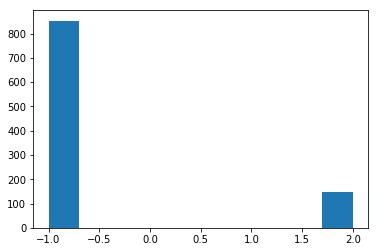

```python
import time
import matplotlib.pyplot as plt
winner = []
start_time = time.clock()
for i in range(1000):
    winner.append(play_game())

end_time = time.clock()
print(end_time - start_time)
plt.hist(winner)
plt.show()
```

### Answer As per DataCamp

play_game?? (type this at ipython prompt)

```python
def play_game():
    board, winner = create_board(), 0
    while winner == 0:
        for player in [1, 2]:
            random_place(board, player)
            winner = evaluate(board)
            if winner != 0:
                break
    return winner

def random_place(board, player):
    selections = possibilities(board)
    if len(selections) > 0:
        selection = random.choice(selections)
        place(board, player, selection)
    return board

def possibilities(board):
    return list(zip(*np.where(board == 0)))

def place(board, player, position):
    if board[position] == 0:
        board[position] = player
        return board

def evaluate(board):
    winner = 0
    for player in [1, 2]:
        if row_win(board, player) or col_win(board, player) or diag_win(board, player):
            winner = player
    if np.all(board != 0) and winner == 0:
        winner = -1
    return winner
```

### Exercise 12

Tic-tac-toe (or noughts and crosses) is a simple strategy game in which two players take turns placing a mark on a 3x3 board, attempting to make a row, column, or diagonal of three with their mark. In this homework, we will use the tools we've covered in the past two weeks to create a tic-tac-toe simulator and evaluate basic winning strategies.

```python
def play_strategic_game():
    board, winner = create_board(), 0
    board[1,1] = 1
    while winner == 0:
        for player in [2,1]:
            # use `random_place` to play a game, and store as `board`.
            # use `evaluate(board)`, and store as `winner`.
            random_place(board, player)
            winner = evaluate(board)
            if winner != 0:
                break
    return winner

play_strategic_game()
```

```
1
```

### Exercise 13

Tic-tac-toe (or noughts and crosses) is a simple strategy game in which two players take turns placing a mark on a 3x3 board, attempting to make a row, column, or diagonal of three with their mark. In this homework, we will use the tools we've covered in the past two weeks to create a tic-tac-toe simulator and evaluate basic winning strategies.

- The results from Exercise 12 have been stored. Use the play_strategic_game() function to play 1,000 random games.
- Use the time libary to evaluate how long all these games takes.
- The library matplotlib.pyplot has already been stored as plt. Use plt.hist and plt.show to plot your results. Did Player 1's performance improve? Does either player win more than each player draws?

```
-0.14263677597045898
```

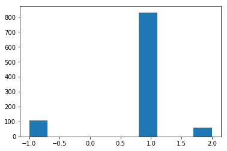

```python
# write your code here!
import time
start = time.time()
games = [play_strategic_game() for i in range(1000)]
stop = time.time()
print(start-stop)
plt.hist(games)
plt.show()
```